# 2020 Fall STAT 430 Final Project --- Wine Data Cluster Analysis

#### 7.1.3.2 Cluster Attributes

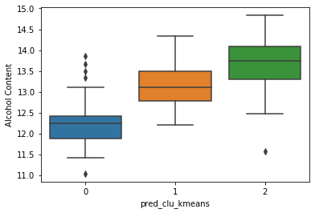

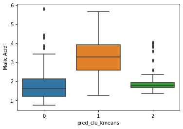

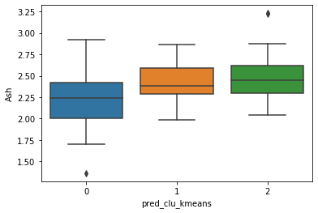

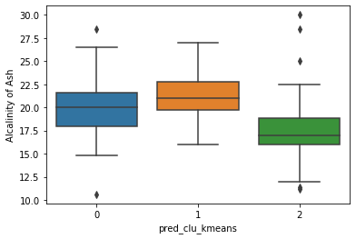

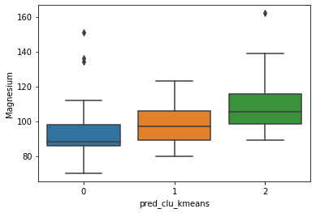

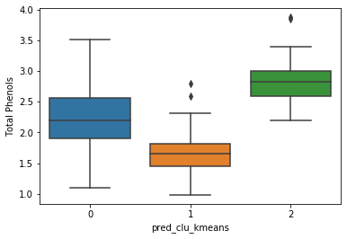

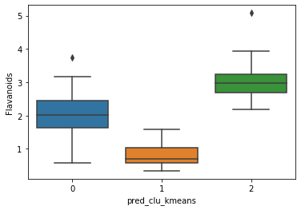

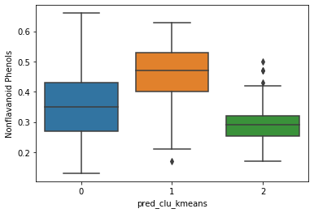

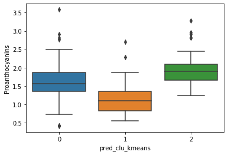

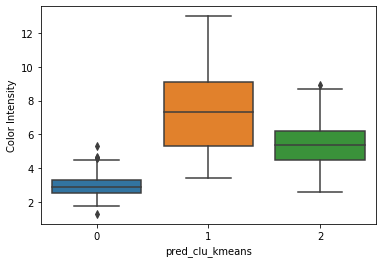

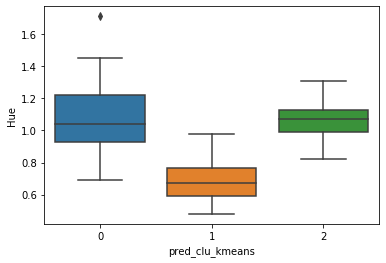

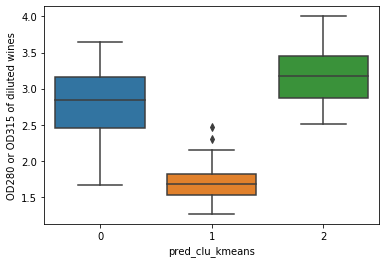

[1 more figures not shown]

```python
sel_feature = list(wine.columns)[1:-1]
for col in sel_feature:
    sns.boxplot(x='pred_clu_kmeans', y=col, data=wine)
    plt.show()
```

Based on the box plot above, we can observe that in the kmeans clustering result:

- Cluster 0 generally has low values of alcohol content, malic acid, magnesium, color intensity, proline; and high values of hue.
- Cluster 1 generally has low values of total phenols, flavanoids, proanthocyanins, hue, OD280 or OD315 of diluted wines; and high values of malic acid, nonflavanoid phenols, color intensity.
- Cluster 2 generally has low values of malic acid, alcalinity of ash, nonflavanoid phenols; and high values of alcohol content, magnesium, total phenols, flavanoids, proanthocyanins, OD280 or OD315 of diluted wines, proline.

The mean value of each variable for each cluster is shown below:

```python
# comparison of mean features of the three classes
compare_mtx = wine.iloc[:,1:].groupby(by='pred_clu_kmeans').mean()
compare_mtx.rename_axis(index={'pred_clu_kmeans': 'cluster id'})
```

| cluster id | Alcohol Content | Malic Acid | Ash | Alcalinity of Ash | Magnesium | Total Phenols | Flavanoids | Nonflavanoid Phenols | Proanthocyanins | Color Intensity | Hue | OD280 or OD315 of diluted wines | Proline |
| --- | --- | --- | --- | --- | --- | --- | --- | --- | --- | --- | --- | --- | --- |
| 0 | 12.250923 | 1.897385 | 2.231231 | 20.063077 | 92.738462 | 2.247692 | 2.050000 | 0.357692 | 1.624154 | 2.973077 | 1.062708 | 2.803385 | 510.169231 |
| 1 | 13.134118 | 3.307255 | 2.417647 | 21.241176 | 98.666667 | 1.683922 | 0.818824 | 0.451961 | 1.145882 | 7.234706 | 0.691961 | 1.696667 | 619.058824 |
| 2 | 13.676774 | 1.997903 | 2.466290 | 17.462903 | 107.967742 | 2.847581 | 3.003226 | 0.292097 | 1.922097 | 5.453548 | 1.065484 | 3.163387 | 1100.225806 |

#### 7.1.3.3 Supervised Learning Evaluation

```python
# Adjusted Rand Score
adjusted_rand_score(wine['pred_clu_kmeans'],wine['Wine Class'])
```

```
0.8974949815093207
```

The Rand Index computes a similarity measure between two clusterings by considering all pairs of samples and counting pairs that are assigned in the same or different clusters in the predicted and true clusterings. The adjusted rand score for the pre-assigned wine class labels and the k-means clustering labels is pretty high.

```python
# Homogeneity Score
homogeneity_score(wine['Wine Class'],wine['pred_clu_kmeans'])
```

```
0.8788432003662366
```

Homogeneity metric of a cluster labeling given a ground truth. A clustering result satisfies homogeneity if all of its clusters contain only data points which are members of a single class. The homogeneity score for the pre-assigned wine class labels and the k-means clustering labels is pretty high.

```python
# Completeness Score
completeness_score(wine['Wine Class'],wine['pred_clu_kmeans'])
```

```
0.8729636016078731
```

Completeness metric of a cluster labeling given a ground truth. A clustering result satisfies completeness if all the data points that are members of a given class are elements of the same cluster. The completeness score for the pre-assigned wine class labels and the k-means clustering labels is pretty high.

```python
# store the evaluation metrics in a dataframe
df_metrics = pd.DataFrame()
df_metrics = df_metrics.append(pd.Series(['Kmeans','Adjusted_rand_score',adjusted_rand_score(wine['pred_clu_kmeans'],wine['Wine Class'])]), ignore_index=True)
df_metrics = df_metrics.append(pd.Series(['Kmeans','Homogeneity_score',homogeneity_score(wine['Wine Class'],wine['pred_clu_kmeans'])]), ignore_index=True)
df_metrics = df_metrics.append(pd.Series(['Kmeans','completeness_score',completeness_score(wine['pred_clu_kmeans'],wine['Wine Class'])]), ignore_index=True)
```

## 7.2 Hierarchical Clustering

### 7.2.1 Parameter Setting

For hierarchical clustering algorithm, we do not need to specify the number of clusters in advance and the result is a dendrogram. However, for the purpose of this project, we need to compare the performance of different algorithms. From pre-analysis, we can see that 3 is a decent number of clusters, thus we will specify the number of clusters to 3. Also, there is an important parameter in hierarchical clustering algorithm which is the method for calculating the distance between the newly formed cluster. Some common methods contain single linkage, complete linkage, average linkage and Ward’s linkage. We first try all the methods and select the one that has the best performance and conduct post analysis on the best method.

### 7.2.2 complete linkage

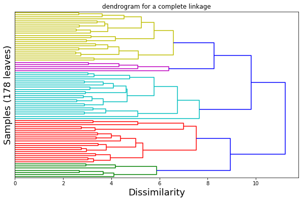

```python
dm = pdist(X_scaled, metric='euclidean')
Z = linkage(dm, method='complete')

fig, ax = plt.subplots(figsize=(10, 6))

d = dendrogram(Z, orientation='right', truncate_mode='lastp', p=80, no_labels=True, ax=ax)

ax.set_xlabel('Dissimilarity', fontsize=18)
ax.set_ylabel('Samples (178 leaves)', fontsize=18)

plt.title("dendrogram for a complete linkage")

plt.show()
```

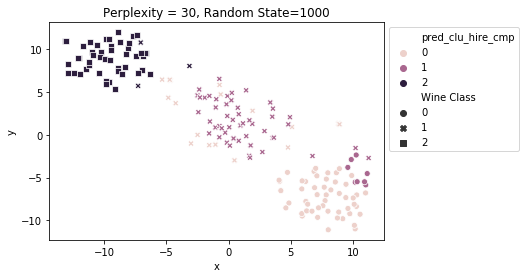

```python
ag = AgglomerativeClustering(n_clusters=3, affinity='euclidean', linkage='complete')
Y_pred = ag.fit_predict(X_scaled)
wine['pred_clu_hire_cmp']=Y_pred
dff = pd.concat([wine, df_tsne], axis=1)
# Plot the projected (x,y) coordinates
sns.scatterplot(x='x', y='y', hue='pred_clu_hire_cmp', style='Wine Class', data=dff)
plt.title('Perplexity = 30, Random State=1000')
plt.legend(bbox_to_anchor=(1,1))
plt.show()
```

```python
# Adjusted Rand Score
print(adjusted_rand_score(wine['pred_clu_hire_cmp'],wine['Wine Class']))
# Homogeneity Score
print(homogeneity_score(wine['Wine Class'],wine['pred_clu_hire_cmp']))
# Completeness Score
print(completeness_score(wine['Wine Class'],wine['pred_clu_hire_cmp']))
```

```
0.5771435822032458
0.6157450578969594
0.6130164142738914
```

### 7.2.3 Single linkage

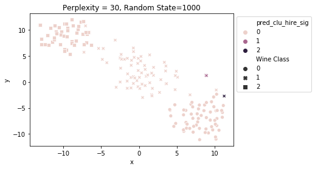

```python
ag = AgglomerativeClustering(n_clusters=3, affinity='euclidean', linkage='single')
Y_pred = ag.fit_predict(X_scaled)
wine['pred_clu_hire_sig']=Y_pred
dff = pd.concat([wine, df_tsne], axis=1)
# Plot the projected (x,y) coordinates
sns.scatterplot(x='x', y='y', hue='pred_clu_hire_sig', style='Wine Class', data=dff)
plt.title('Perplexity = 30, Random State=1000')
plt.legend(bbox_to_anchor=(1,1))
plt.show()
```

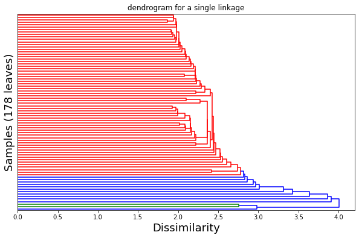

```python
dm = pdist(X_scaled, metric='euclidean')
Z = linkage(dm, method='single')

fig, ax = plt.subplots(figsize=(10, 6))

d = dendrogram(Z, orientation='right', truncate_mode='lastp', p=80, no_labels=True, ax=ax)

ax.set_xlabel('Dissimilarity', fontsize=18)
ax.set_ylabel('Samples (178 leaves)', fontsize=18)

plt.title("dendrogram for a single linkage")

plt.show()
```

```python
# Adjusted Rand Score
print(adjusted_rand_score(wine['pred_clu_hire_sig'],wine['Wine Class']))
# Homogeneity Score
print(homogeneity_score(wine['Wine Class'],wine['pred_clu_hire_sig']))
# Completeness Score
print(completeness_score(wine['Wine Class'],wine['pred_clu_hire_sig']))
```

```
-0.006814188896712388
0.019377633193659035
0.17516047119000575
```

### 7.2.3 Average linkage

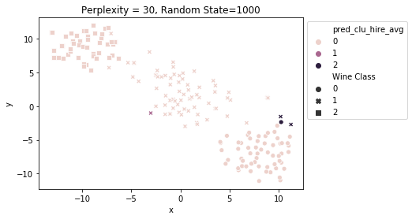

```python
ag = AgglomerativeClustering(n_clusters=3, affinity='euclidean', linkage='average')
Y_pred = ag.fit_predict(X_scaled)
wine['pred_clu_hire_avg']=Y_pred
dff = pd.concat([wine, df_tsne], axis=1)
# Plot the projected (x,y) coordinates
sns.scatterplot(x='x', y='y', hue='pred_clu_hire_avg', style='Wine Class', data=dff)
plt.title('Perplexity = 30, Random State=1000')
plt.legend(bbox_to_anchor=(1,1))
plt.show()
```

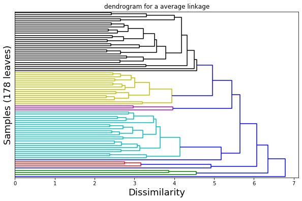

```python
# Show the truncated dendrogram for a average linkage
dm = pdist(X_scaled, metric='euclidean')
Z = linkage(dm, method='average')

fig, ax = plt.subplots(figsize=(10, 6))

d = dendrogram(Z, orientation='right', truncate_mode='lastp', p=80, no_labels=True, ax=ax)

ax.set_xlabel('Dissimilarity', fontsize=18)
ax.set_ylabel('Samples (178 leaves)', fontsize=18)

plt.title("dendrogram for a average linkage")

plt.show()
```

```python
# Adjusted Rand Score
print(adjusted_rand_score(wine['pred_clu_hire_avg'],wine['Wine Class']))
# Homogeneity Score
print(homogeneity_score(wine['Wine Class'],wine['pred_clu_hire_avg']))
# Completeness Score
print(completeness_score(wine['Wine Class'],wine['pred_clu_hire_avg']))
```

```
-0.005441973296580575
0.010240007733926266
0.09256262422444676
```

### 7.2.4 Ward linkage

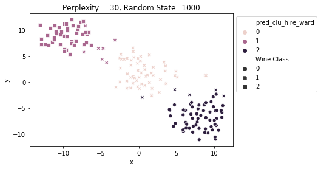

```python
ag = AgglomerativeClustering(n_clusters=3, affinity='euclidean', linkage='ward')
Y_pred = ag.fit_predict(X_scaled)
wine['pred_clu_hire_ward']=Y_pred
dff = pd.concat([wine, df_tsne], axis=1)
# Plot the projected (x,y) coordinates
sns.scatterplot(x='x', y='y', hue='pred_clu_hire_ward', style='Wine Class', data=dff)
plt.title('Perplexity = 30, Random State=1000')
plt.legend(bbox_to_anchor=(1,1))
plt.show()
```

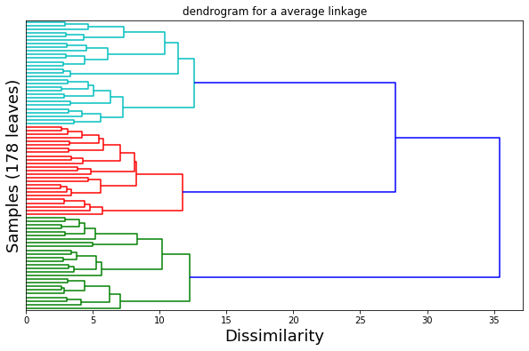

```python
# Show the truncated dendrogram for a average linkage
dm = pdist(X_scaled, metric='euclidean')
Z = linkage(dm, method='ward')

fig, ax = plt.subplots(figsize=(10, 6))

d = dendrogram(Z, orientation='right', truncate_mode='lastp', p=80, no_labels=True, ax=ax)

ax.set_xlabel('Dissimilarity', fontsize=18)
ax.set_ylabel('Samples (178 leaves)', fontsize=18)

plt.title("dendrogram for a average linkage")

plt.show()
```

```python
# Adjusted Rand Score
print(adjusted_rand_score(wine['pred_clu_hire_ward'],wine['Wine Class']))
# Homogeneity Score
print(homogeneity_score(wine['Wine Class'],wine['pred_clu_hire_ward']))
# Completeness Score
print(completeness_score(wine['Wine Class'],wine['pred_clu_hire_ward']))
```

```
0.7899332213582837
0.7904292718316542
0.7825408201875714
```

Similar size, similar structure, distribution

### 7.2.5 Hierarchical Clustering Post Analysis

The "Ward" linkage has the best performance and we will use this for the result of our Hierarchical Clustering algorithm.

#### 7.2.5.1 Separation and Cohesion

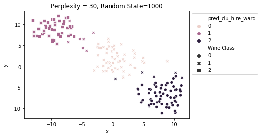

```python
ag = AgglomerativeClustering(n_clusters=3, affinity='euclidean', linkage='ward')
Y_pred = ag.fit_predict(X_scaled)
wine['pred_clu_hire_ward']=Y_pred
dff = pd.concat([wine, df_tsne], axis=1)
# Plot the projected (x,y) coordinates
sns.scatterplot(x='x', y='y', hue='pred_clu_hire_ward', style='Wine Class', data=dff)
plt.title('Perplexity = 30, Random State=1000')
plt.legend(bbox_to_anchor=(1,1))
plt.show()
```

It looks like the hierarchical clustering algorithm with Ward linkage identified the three clusters that we expected we would find given the t-sne plot.

The t-SNE plot colored by the predicted cluster labels shows that there is no strong cohesion and separation for the three clusters. Compared to cluster 0 and cluster 1, cluster 2 has less cohesion since we could see some points that are far from cluster 2 are very close to the other two clusters.

However, compared to the result of the K-Means algorithm, the hierarchical clustering result has less cohesion and separation since there are more points that are not well separated. Also, there are more samples that are wrongly classified.

```python
# silhouette score for assessing cohesion and separation of individual objects in a given clustering
silhouette_avg_hire = silhouette_score(X_scaled, wine['pred_clu_hire_ward'])
print("The average silhouette_score for the K-Means is :", silhouette_avg_hire)
```

```
The average silhouette_score for the K-Means is : 0.2774439826952265
```

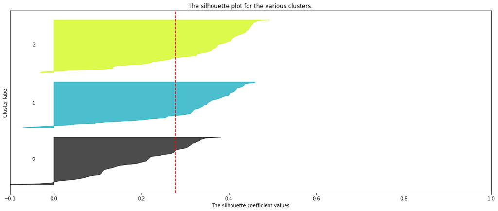

```python
# Compute the silhouette scores for each sample
sample_silhouette_values = silhouette_samples(X_scaled, wine['pred_clu_hire_ward'])

n_clusters=len(wine['pred_clu_hire_ward'].unique())


fig, ax1 = plt.subplots(1, 1)
fig.set_size_inches(18, 7)

# The 1st subplot is the silhouette plot
# The silhouette coefficient can range from -1, 1 but in this example all
# lie within [-0.1, 1]
ax1.set_xlim([-0.1, 1])
# The (n_clusters+1)*10 is for inserting blank space between silhouette
# plots of individual clusters, to demarcate them clearly.
ax1.set_ylim([0, len(X) + (n_clusters + 1) * 10])


y_lower = 10
for i in range(n_clusters):
    # Aggregate the silhouette scores for samples belonging to
    # cluster i, and sort them
    ith_cluster_silhouette_values = \
        sample_silhouette_values[wine['pred_clu_hire_ward'] == i]

    ith_cluster_silhouette_values.sort()

    size_cluster_i = ith_cluster_silhouette_values.shape[0]
    y_upper = y_lower + size_cluster_i

    color = cm.nipy_spectral(float(i) / n_clusters)
    ax1.fill_betweenx(np.arange(y_lower, y_upper),
                      0, ith_cluster_silhouette_values,
                      facecolor=color, edgecolor=color, alpha=0.7)

    # Label the silhouette plots with their cluster numbers at the middle
    ax1.text(-0.05, y_lower + 0.5 * size_cluster_i, str(i))

    # Compute the new y_lower for next plot
    y_lower = y_upper + 10  # 10 for the 0 samples

ax1.set_title("The silhouette plot for the various clusters.")
ax1.set_xlabel("The silhouette coefficient values")
ax1.set_ylabel("Cluster label")

# The vertical line for average silhouette score of all the values
ax1.axvline(x=silhouette_avg_hire, color="red", linestyle="--")

ax1.set_yticks([])  # Clear the yaxis labels / ticks
ax1.set_xticks([-0.1, 0, 0.2, 0.4, 0.6, 0.8, 1])


plt.show()
```

The closer this score is to 1, the more cohesive and separated these clustering is. So an average silhouette score of 0.27 is somewhat low. So even though the t-SNE plot shows that the class labels are almost correctly predicted, the underlying cohesion and separation of this dataset is not strong, in which there are some connections among different kinds of wines.

#### 7.2.5.2 Cluster Attributes

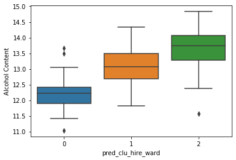

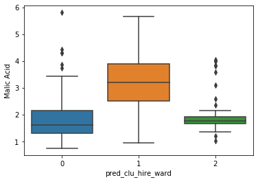

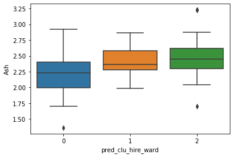

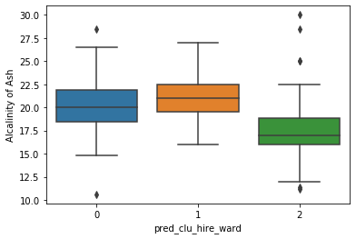

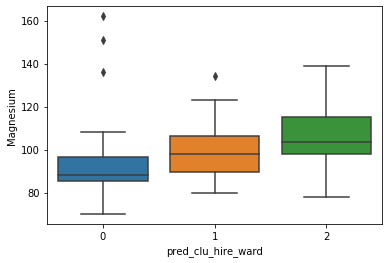

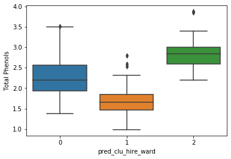

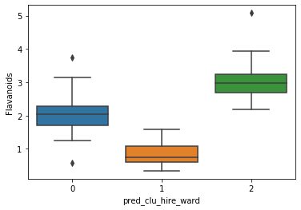

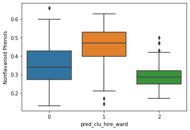

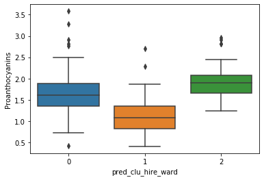

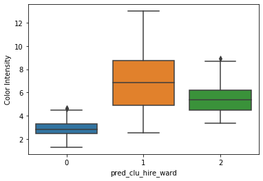

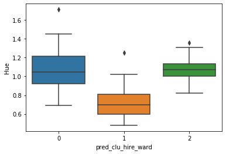

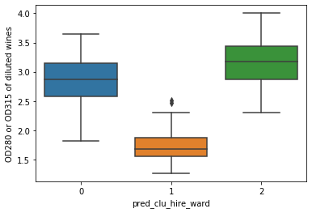

[1 more figures not shown]

```python
sel_feature = list(wine.columns)[1:-5]
for col in sel_feature:
    sns.boxplot(x='pred_clu_hire_ward', y=col, data=wine[['Wine Class', 'Alcohol Content', 'Malic Acid', 'Ash',
       'Alcalinity of Ash', 'Magnesium', 'Total Phenols', 'Flavanoids',
       'Nonflavanoid Phenols', 'Proanthocyanins', 'Color Intensity', 'Hue',
       'OD280 or OD315 of diluted wines', 'Proline', 'pred_clu_hire_ward']])
    plt.show()
```

Based on the box plot above, we can observe that in the hierarchical clustering result:

- Cluster 0 generally has low values of alcohol content, malic acid, magnesium, color intensity, proline; and high values of hue.
- Cluster 1 generally has low values of total phenols, flavanoids, proanthocyanins, hue, OD280 or OD315 of diluted wines; and high values of malic acid, nonflavanoid phenols, color intensity.
- Cluster 2 generally has low values of malic acid, alcalinity of ash, nonflavanoid phenols; and high values of alcohol content, magnesium, total phenols, flavanoids, proanthocyanins, OD280 or OD315 of diluted wines, proline.

The mean value of each variable for each cluster is shown below:

```python
# comparison of mean features of the three classes
compare_mtx = wine.iloc[:,1:].groupby(by='pred_clu_hire_ward')['Alcohol Content', 'Malic Acid', 'Ash',
       'Alcalinity of Ash', 'Magnesium', 'Total Phenols', 'Flavanoids',
       'Nonflavanoid Phenols', 'Proanthocyanins', 'Color Intensity', 'Hue',
       'OD280 or OD315 of diluted wines', 'Proline'].mean()
compare_mtx.rename_axis(index={'pred_clu_hire_ward': 'cluster id'})
```

| cluster id | Alcohol Content | Malic Acid | Ash | Alcalinity of Ash | Magnesium | Total Phenols | Flavanoids | Nonflavanoid Phenols | Proanthocyanins | Color Intensity | Hue | OD280 or OD315 of diluted wines | Proline |
| --- | --- | --- | --- | --- | --- | --- | --- | --- | --- | --- | --- | --- | --- |
| 0 | 12.203966 | 1.938966 | 2.215172 | 20.208621 | 92.551724 | 2.262931 | 2.088103 | 0.355345 | 1.686552 | 2.895345 | 1.060000 | 2.862241 | 501.431034 |
| 1 | 13.061607 | 3.166607 | 2.412857 | 21.003571 | 99.857143 | 1.694286 | 0.847857 | 0.449464 | 1.129286 | 6.850179 | 0.721000 | 1.727321 | 624.946429 |
| 2 | 13.669219 | 1.970000 | 2.463125 | 17.528125 | 106.156250 | 2.850000 | 3.009688 | 0.291094 | 1.908125 | 5.450000 | 1.071406 | 3.158438 | 1076.046875 |

#### 7.2.5.3 Supervised Learning Evaluation

```python
# Adjusted Rand Score
print(adjusted_rand_score(wine['pred_clu_hire_ward'],wine['Wine Class']))
# Homogeneity Score
print(homogeneity_score(wine['Wine Class'],wine['pred_clu_hire_ward']))
# Completeness Score
print(completeness_score(wine['Wine Class'],wine['pred_clu_hire_ward']))
```

```
0.7899332213582837
0.7904292718316542
0.7825408201875714
```

```python
# store the evaluation metrics into the dataframe
df_metrics = df_metrics.append(pd.Series(['Hierarchical','Adjusted_rand_score',adjusted_rand_score(wine['pred_clu_hire_ward'],wine['Wine Class'])]), ignore_index=True)
df_metrics = df_metrics.append(pd.Series(['Hierarchical','Homogeneity_score',homogeneity_score(wine['Wine Class'],wine['pred_clu_hire_ward'])]), ignore_index=True)
df_metrics = df_metrics.append(pd.Series(['Hierarchical','completeness_score',completeness_score(wine['pred_clu_hire_ward'],wine['Wine Class'])]), ignore_index=True)
```

## 7.3 Fuzzy c-means (FCM)

### 7.3.1 Parameter Setting

- From pre-analysis, we can see that 3 is a decent number of clusters, thus we will specify the number of clusters to 3.
- For the fuzziness parameter p, we know that the more this parameter is closer to 1, the less fuzzy the clustering will be. On the contrary, the more this parameter is closer to infinity, the fuzzier the cluster will be. In this case, we tried different values for p and see what value will give us the most decent fuzziness, and plot 3 t-sne plots for each value of p along the way.

### 7.3.2 Results Presentation

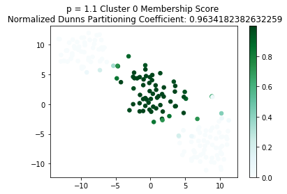

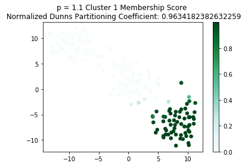

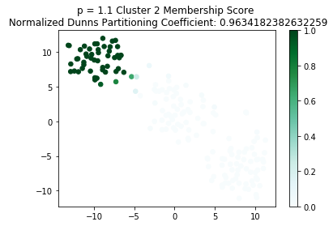

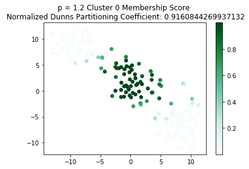

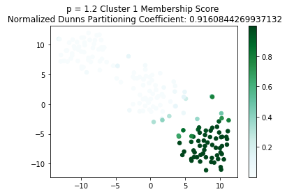

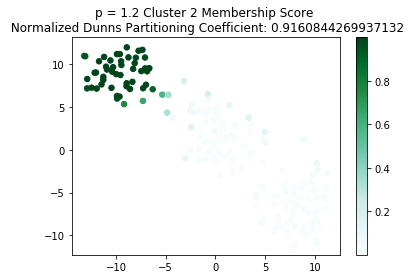

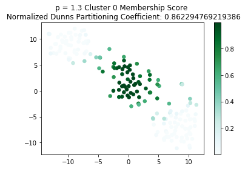

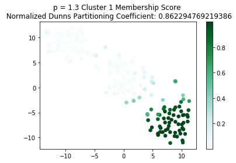

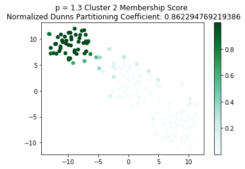

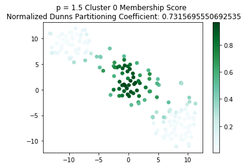

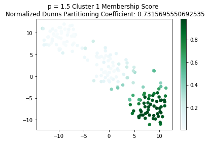

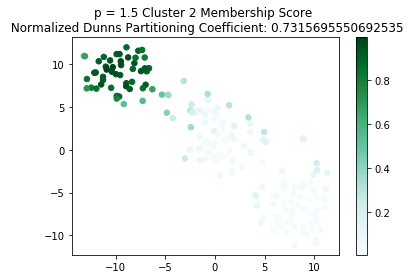

```python
X_array=np.array(X_scaled).T
# Number of clusters
K=3
for p in [1.1,1.2,1.3,1.5]:
    cntr, W, _, _, _, _, pc = cmeans(X_array, c=K, m=p, error=1e-6, maxiter=20000, seed=1000)
    for i in range(0,K):
        dff['Cluster %s Membership Score'%str(i)]=W[i,:]
        # Plot the projected (x,y) coordinates
        points = plt.scatter(dff["x"], dff["y"],
                 c=dff['Cluster %s Membership Score'%str(i)], s=30, cmap="BuGn")
        plt.colorbar(points)
        plt.title('p = %s Cluster %s Membership Score \n Normalized Dunns Partitioning Coefficient: %s'%(p,str(i),pc))
        plt.show()
    print('----------------------------------------')
```

Out of the four values of p that we tested here, when p=1.1, the partition is too hard; when p=1.5, the partition is too fuzzy; it looks like p=1.3 best captures the cluster assignment uncertainty of some of the objects that we can see reflected in the t-sne plots. The normalized Dunn's partitioning coefficient value for the fuzzy c-means clustering algorithm with p=1.3 was 0.8623. This value of 0.8623 is fairly close to 1, which reflects a reasonable assignment (not too fuzzy and not too hard).

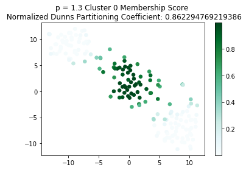

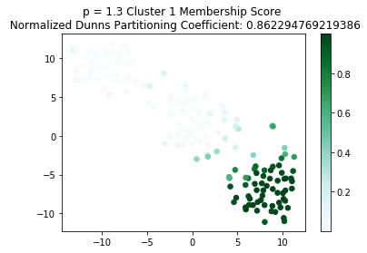

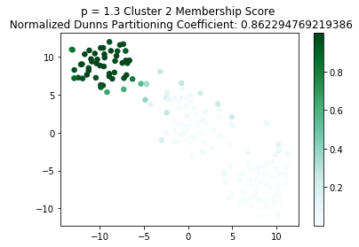

```python
# Number of clusters
K=3
p=1.3
cntr, W, _, _, _, _, pc = cmeans(X_array, c=K, m=p, error=1e-6, maxiter=20000, seed=1000)
for i in range(0,K):
    dff['Cluster %s Membership Score'%str(i)]=W[i,:]
    # Plot the projected (x,y) coordinates
    points = plt.scatter(dff["x"], dff["y"],
    c=dff['Cluster %s Membership Score'%str(i)], s=30, cmap="BuGn")
    plt.colorbar(points)
    plt.title('p = %s Cluster %s Membership Score \n Normalized Dunns Partitioning Coefficient: %s'%(p,str(i),pc))
    plt.show()
    print('----------------------------------------')
```

```python
wine['pred_fuzzy_cmeans']=np.argmax(W, axis=0)
```

### 7.3.3 Fuzzy c-means Post Analysis

#### 7.3.3.1 Separation and Cohesion

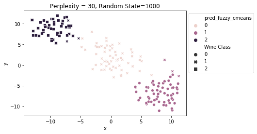

```python
dff = pd.concat([wine, df_tsne], axis=1)
# Plot the projected (x,y) coordinates
sns.scatterplot(x='x', y='y', hue='pred_fuzzy_cmeans', style='Wine Class', data=dff)
plt.title('Perplexity = 30, Random State=1000')
plt.legend(bbox_to_anchor=(1,1))
plt.show()
```

```python
# silhouette score for assessing cohesion and separation of individual objects in a given clustering
silhouette_avg_fuz = silhouette_score(X_scaled, wine['pred_fuzzy_cmeans'])
print("The average silhouette_score for the K-Means is :", silhouette_avg_fuz)
```

```
The average silhouette_score for the K-Means is : 0.2848589191898987
```

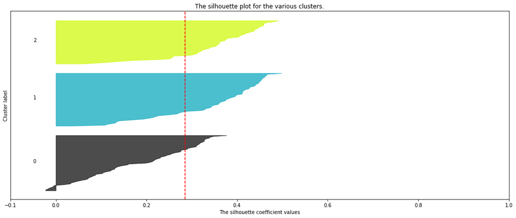

```python
# Compute the silhouette scores for each sample
sample_silhouette_values = silhouette_samples(X_scaled, wine['pred_fuzzy_cmeans'])

n_clusters=len(wine['pred_fuzzy_cmeans'].unique())


fig, ax1 = plt.subplots(1, 1)
fig.set_size_inches(18, 7)

# The 1st subplot is the silhouette plot
# The silhouette coefficient can range from -1, 1 but in this example all
# lie within [-0.1, 1]
ax1.set_xlim([-0.1, 1])
# The (n_clusters+1)*10 is for inserting blank space between silhouette
# plots of individual clusters, to demarcate them clearly.
ax1.set_ylim([0, len(X) + (n_clusters + 1) * 10])


y_lower = 10
for i in range(n_clusters):
    # Aggregate the silhouette scores for samples belonging to
    # cluster i, and sort them
    ith_cluster_silhouette_values = \
        sample_silhouette_values[wine['pred_fuzzy_cmeans'] == i]

    ith_cluster_silhouette_values.sort()

    size_cluster_i = ith_cluster_silhouette_values.shape[0]
    y_upper = y_lower + size_cluster_i

    color = cm.nipy_spectral(float(i) / n_clusters)
    ax1.fill_betweenx(np.arange(y_lower, y_upper),
                      0, ith_cluster_silhouette_values,
                      facecolor=color, edgecolor=color, alpha=0.7)

    # Label the silhouette plots with their cluster numbers at the middle
    ax1.text(-0.05, y_lower + 0.5 * size_cluster_i, str(i))

    # Compute the new y_lower for next plot
    y_lower = y_upper + 10  # 10 for the 0 samples

ax1.set_title("The silhouette plot for the various clusters.")
ax1.set_xlabel("The silhouette coefficient values")
ax1.set_ylabel("Cluster label")

# The vertical line for average silhouette score of all the values
ax1.axvline(x=silhouette_avg_fuz, color="red", linestyle="--")

ax1.set_yticks([])  # Clear the yaxis labels / ticks
ax1.set_xticks([-0.1, 0, 0.2, 0.4, 0.6, 0.8, 1])


plt.show()
```

#### 7.3.3.2 Cluster Attributes

```python
wine.columns
```

```
Index(['Wine Class', 'Alcohol Content', 'Malic Acid', 'Ash',
       'Alcalinity of Ash', 'Magnesium', 'Total Phenols', 'Flavanoids',
       'Nonflavanoid Phenols', 'Proanthocyanins', 'Color Intensity', 'Hue',
       'OD280 or OD315 of diluted wines', 'Proline', 'pred_clu_kmeans',
       'pred_clu_hire_cmp', 'pred_clu_hire_sig', 'pred_clu_hire_avg',
       'pred_clu_hire_ward', 'pred_fuzzy_cmeans'],
      dtype='object')
```

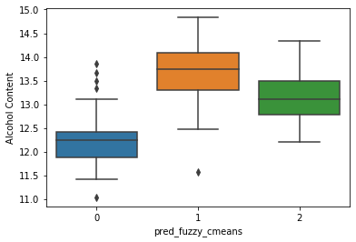

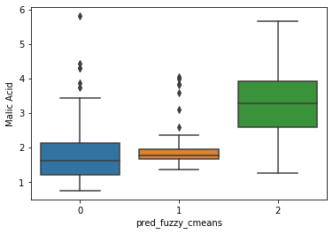

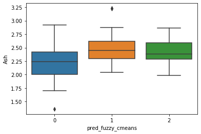

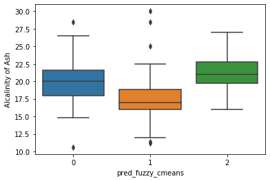

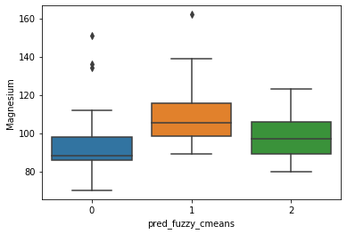

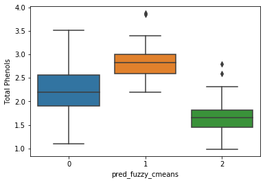

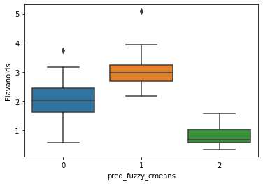

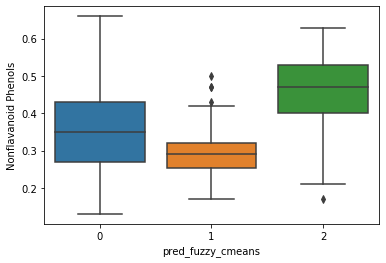

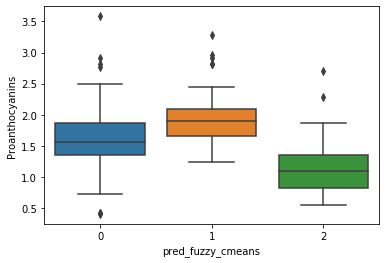

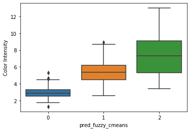

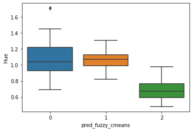

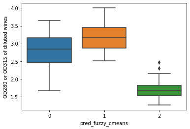

[1 more figures not shown]

```python
sel_feature = list(wine.columns)[1:-6]
for col in sel_feature:
    sns.boxplot(x='pred_fuzzy_cmeans', y=col, data=wine[['Wine Class', 'Alcohol Content', 'Malic Acid', 'Ash',
       'Alcalinity of Ash', 'Magnesium', 'Total Phenols', 'Flavanoids',
       'Nonflavanoid Phenols', 'Proanthocyanins', 'Color Intensity', 'Hue',
       'OD280 or OD315 of diluted wines', 'Proline', 'pred_fuzzy_cmeans']])
    plt.show()
```

Based on the box plot above, we can observe that in the fuzzy cmeans clustering result:

- Cluster 0 generally has low values of alcohol content, malic acid, magnesium, color intensity, proline; and high values of hue.
- Cluster 1 generally has low values of malic acid, alcalinity of ash, nonflavanoid phenols; and high values of alcohol content, magnesium, total phenols, flavanoids, proanthocyanins, OD280 or OD315 of diluted wines, proline.
- Cluster 2 generally has low values of total phenols, flavanoids, proanthocyanins, hue, OD280 or OD315 of diluted wines; and high values of malic acid, nonflavanoid phenols, color intensity.

The mean value of each variable for each cluster is shown below:

```python
# comparison of mean features of the three classes
compare_mtx = wine.iloc[:,1:].groupby(by='pred_fuzzy_cmeans')['Alcohol Content', 'Malic Acid', 'Ash',
       'Alcalinity of Ash', 'Magnesium', 'Total Phenols', 'Flavanoids',
       'Nonflavanoid Phenols', 'Proanthocyanins', 'Color Intensity', 'Hue',
       'OD280 or OD315 of diluted wines', 'Proline'].mean()
compare_mtx.rename_axis(index={'pred_fuzzy_cmeans': 'cluster id'})
```

| cluster id | Alcohol Content | Malic Acid | Ash | Alcalinity of Ash | Magnesium | Total Phenols | Flavanoids | Nonflavanoid Phenols | Proanthocyanins | Color Intensity | Hue | OD280 or OD315 of diluted wines | Proline |
| --- | --- | --- | --- | --- | --- | --- | --- | --- | --- | --- | --- | --- | --- |
| 0 | 12.250923 | 1.897385 | 2.231231 | 20.063077 | 92.738462 | 2.247692 | 2.050000 | 0.357692 | 1.624154 | 2.973077 | 1.062708 | 2.803385 | 510.169231 |
| 1 | 13.676774 | 1.997903 | 2.466290 | 17.462903 | 107.967742 | 2.847581 | 3.003226 | 0.292097 | 1.922097 | 5.453548 | 1.065484 | 3.163387 | 1100.225806 |
| 2 | 13.134118 | 3.307255 | 2.417647 | 21.241176 | 98.666667 | 1.683922 | 0.818824 | 0.451961 | 1.145882 | 7.234706 | 0.691961 | 1.696667 | 619.058824 |

#### 7.3.3.3 Supervised Learning Evaluation

```python
# Adjusted Rand Score
print(adjusted_rand_score(wine['Wine Class'],wine['pred_fuzzy_cmeans']))
# Homogeneity Score
print(homogeneity_score(wine['Wine Class'],wine['pred_fuzzy_cmeans']))
# Completeness Score
print(completeness_score(wine['Wine Class'],wine['pred_fuzzy_cmeans']))
```

```
0.8974949815093207
0.8788432003662366
0.8729636016078731
```

```python
# store the evaluation metrics into the dataframe
df_metrics = df_metrics.append(pd.Series(['Fuzzy_cmeans','Adjusted_rand_score',adjusted_rand_score(wine['pred_fuzzy_cmeans'],wine['Wine Class'])]), ignore_index=True)
df_metrics = df_metrics.append(pd.Series(['Fuzzy_cmeans','Homogeneity_score',homogeneity_score(wine['Wine Class'],wine['pred_fuzzy_cmeans'])]), ignore_index=True)
df_metrics = df_metrics.append(pd.Series(['Fuzzy_cmeans','completeness_score',completeness_score(wine['pred_fuzzy_cmeans'],wine['Wine Class'])]), ignore_index=True)
df_metrics.rename(columns={0: "Method", 1:"Metric", 2:"Value"}, inplace = True)
```

# 8. Analysis Summary

## 8.1 Algorithm comparison summary

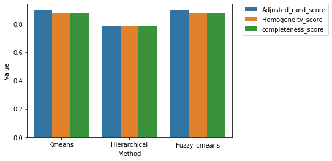

```python
sns.barplot(x="Method", y="Value", hue="Metric", data=df_metrics);
plt.legend(bbox_to_anchor=(1.05, 1), loc=2, borderaxespad=0.);
```

Our research motivation is to use different types of clustering algorithm to grouup similar observations together, and to compare our clustering results with the ground truth. Based on the adjusted rand score, homogeneity score, and completeness score for all 3 types of clustering algorithm we have tried, kmeans clustering and fuzzy cmeans clustering are the better algorithms. Their only difference is that kmeans clustering gives us a hard assignment, while fuzzy cmeans clustering gives us a soft assignment (membership scores for each cluster). It seems that hierarchical clustering is not performing as well as the other two clustering algorithms.

## 8.2 Insights summary

- If we were to perform hard assignment on Fuzzy C-Means, the result would be very similar to the K-Means clustering algorithm.
- For hierarchical clustering, different linkages will lead to different performances. The linkage should be determined by the shape of our dataset (t-SNE) plot.
- For any future new wine data, if we would like to know which cultivar this new wine comes from, we can utilize the K-means clustering results and calculate the distance between this new data and each of the three centroids. Then whichever class that has the shortest distance between its centriod and this new point should be the predicted class.

# 9. Team Member Project Contribution Report

Shuyu Jia:

- Estimated percent contribution: **50%**
- A brief description of the contributions:
  - Dataset Introduction
  - Dataset Research
  - Data Cleaning
  - Algorithm Selection Motivation
  - Fuzzy c-means Algorithm and post analysis
  - Analysis Summary
  - PPT, Presentation, and Report

Zhehui Chen:

- Estimated percent contribution: **50%**
- A brief description of the contributions:
  - Dataset Suitability Pre-Analysis
  - Preliminary EDA
  - Pre-Analysis Questions
  - K-means clustering and post analysis
  - Hierarchical clustering and post analysis
  - PPT, Presentation, and Report